# Making plots with `ggplot2`: Barplots and Scatterplots

### To better view text

Display the bars horizontally instead of vertically!

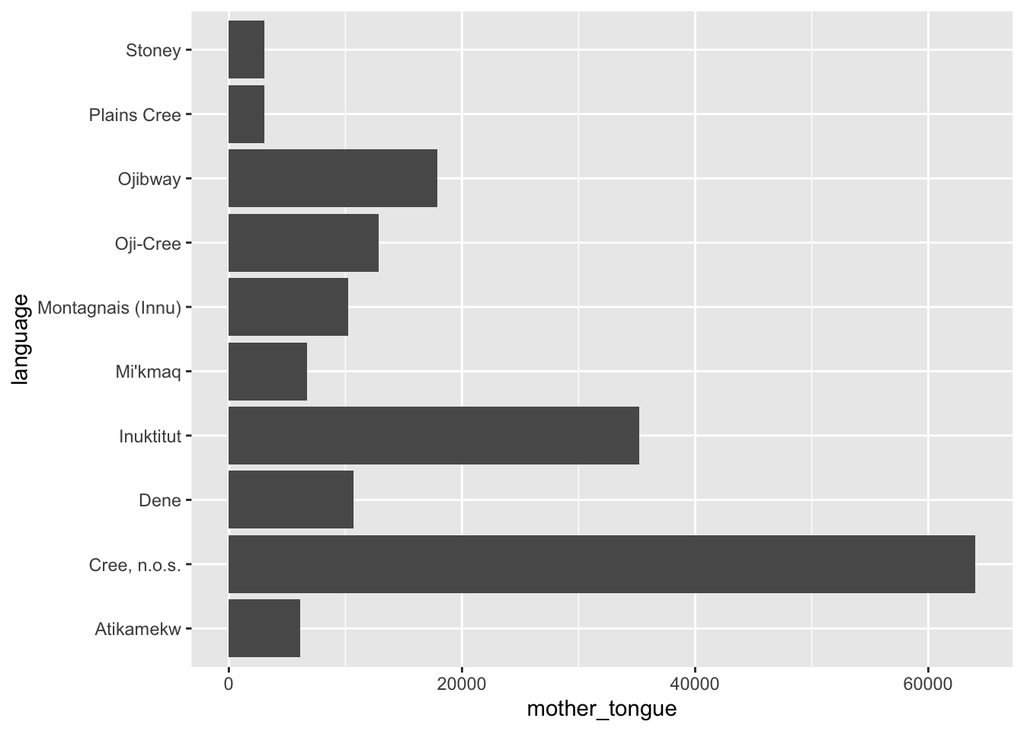

```r
# switch axes to change orientation
ggplot(data=ten_lang) +
  geom_col(aes(y=language, x=mother_tongue))
```

This flips the x and y axes!

## Labels, Colors, and Themes

We can alter the labels on our `x` and `y` axes.

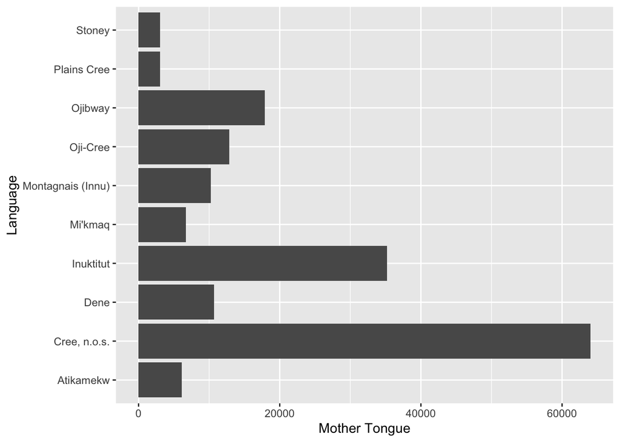

```r
# add axis labels and plot title

# using labs()
ggplot(data=ten_lang) +
  geom_col(aes(y=language, x=mother_tongue)) +
  labs(x="Mother Tongue",
       y="Language")
```

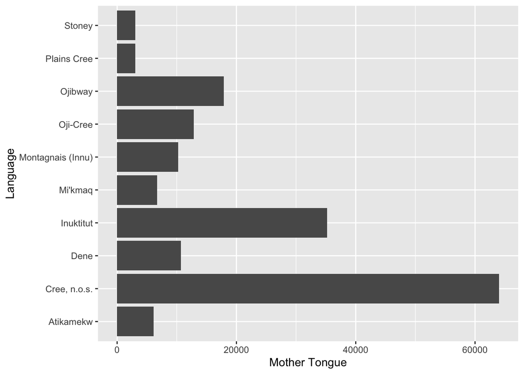

```r
# using xlab() and ylab()
ggplot(data=ten_lang) +
  geom_col(aes(y=language, x=mother_tongue)) +
  xlab("Mother Tongue") +
  ylab("Language")
```

**Tip**

Barplots are good for displaying one categorical variable and one numeric variable. The number variable could be counts (as above) or they could be averages or totals or maximums or minimums (or many other things!)

We can change both the bar fill colors and outline colors displayed on the figure, by adding the `color` and `fill` arguments to our `geom` function.

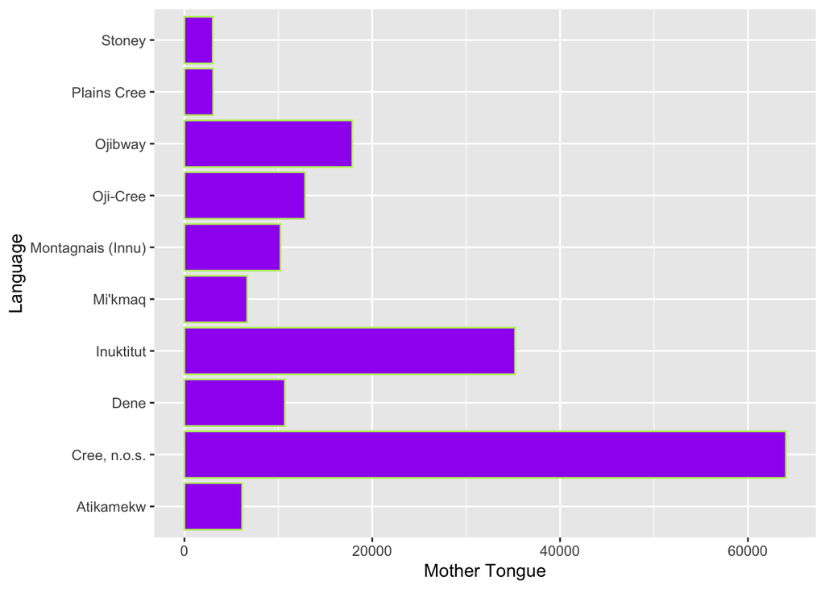

```r
# change bar colors
ggplot(data=ten_lang) +
  geom_col(aes(y=language, x=mother_tongue),
           color="darkolivegreen2",
           fill="purple") +
  labs(x="Mother Tongue",
       y="Language")
```

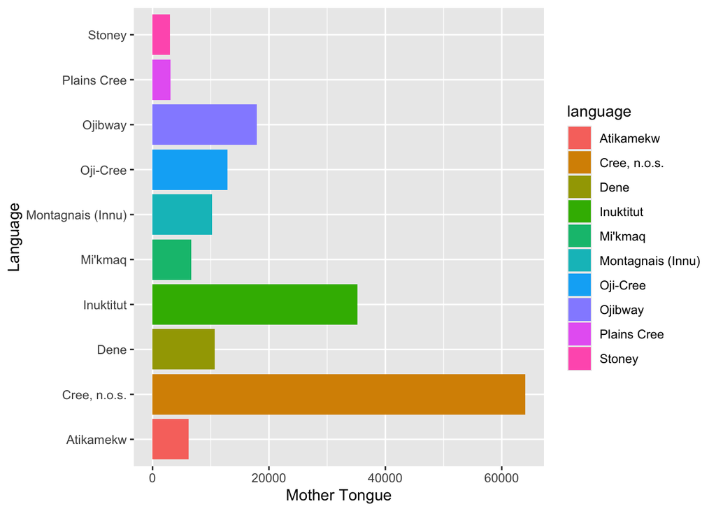

```r
ggplot(data=ten_lang) +
  geom_col(aes(y=language, x=mother_tongue, fill=language)) +
  labs(x="Mother Tongue",
       y="Language")
```

We can further control the appearance of our figures with `themes`.

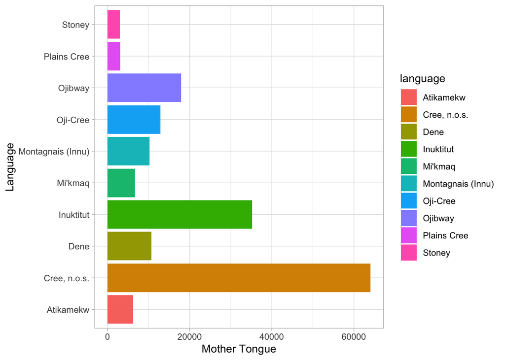

```r
# play around with themes
ggplot(data=ten_lang) +
  geom_col(aes(y=language, x=mother_tongue, fill=language)) +
  labs(x="Mother Tongue",
       y="Language") +
  theme_light()
```

And then finally we can add a title to the figure using the `ggtitle()` function.

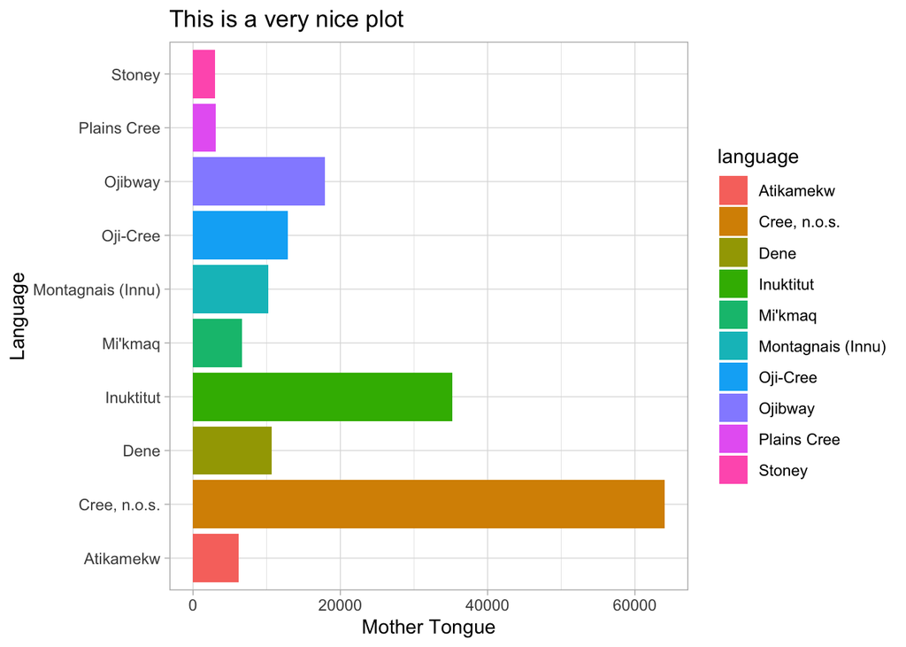

```r
# add a title
ggplot(data=ten_lang) +
  geom_col(aes(y=language, x=mother_tongue, fill=language)) +
  labs(x="Mother Tongue",
       y="Language") +
  ggtitle("This is a very nice plot") +
  theme_light()
```

## ggplot: scatterplot with `geom_point`

The `mtcars` dataset was extracted from the 1974 Motor Trend US magazine, and comprises fuel consumption and 10 aspects of automobile design and performance for 32 automobiles (1973–74 models). It’s available inside the `ggplot` package which is already installed.

```r
#load the data
data(mtcars)

#what is in the dataset???
#?mtcars
```

**Tip**

Scatterplots are good for displaying the relationship between two numerical variables.

### Color and Shape

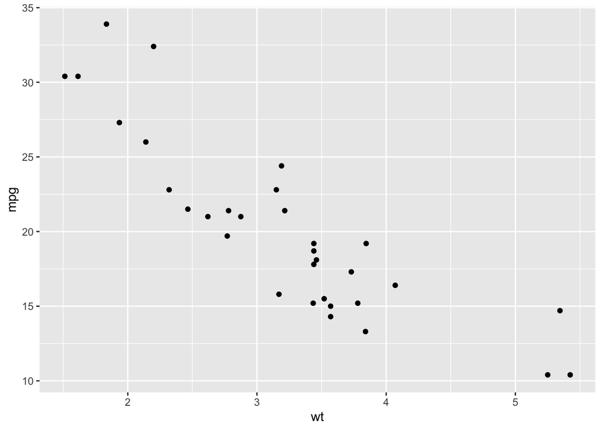

```r
# what should we plot?

mtcars |>
  ggplot() +
  geom_point(aes(x=wt, y=mpg))
```

We can change the shape of the points using the `shape` argument within our `geom_point()` function.

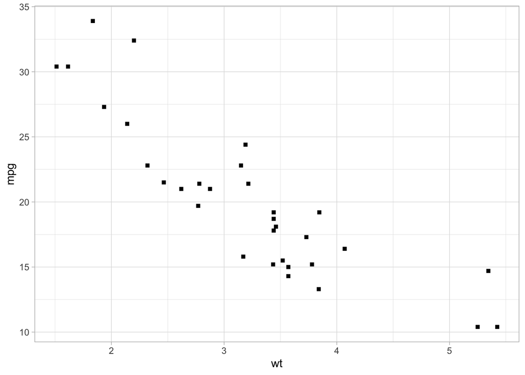

```r
# change shape using pch (stands for plotting character)
# ?pch to get available point shapes

mtcars |>
ggplot() +
  geom_point(aes(x=wt, y=mpg),
             shape=15) +
  theme_light()
```

For reasons that are entirely unclear to me shapes in `R` are referred to as `pch` which stands for plotting character. They are called by number or in some cases name. The `pch` numbers and their corresponding shapes are shown below.

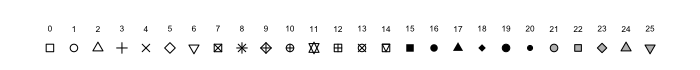

Likewise, we can change the color of our points using the `color` argument within our `geom_point()` function.

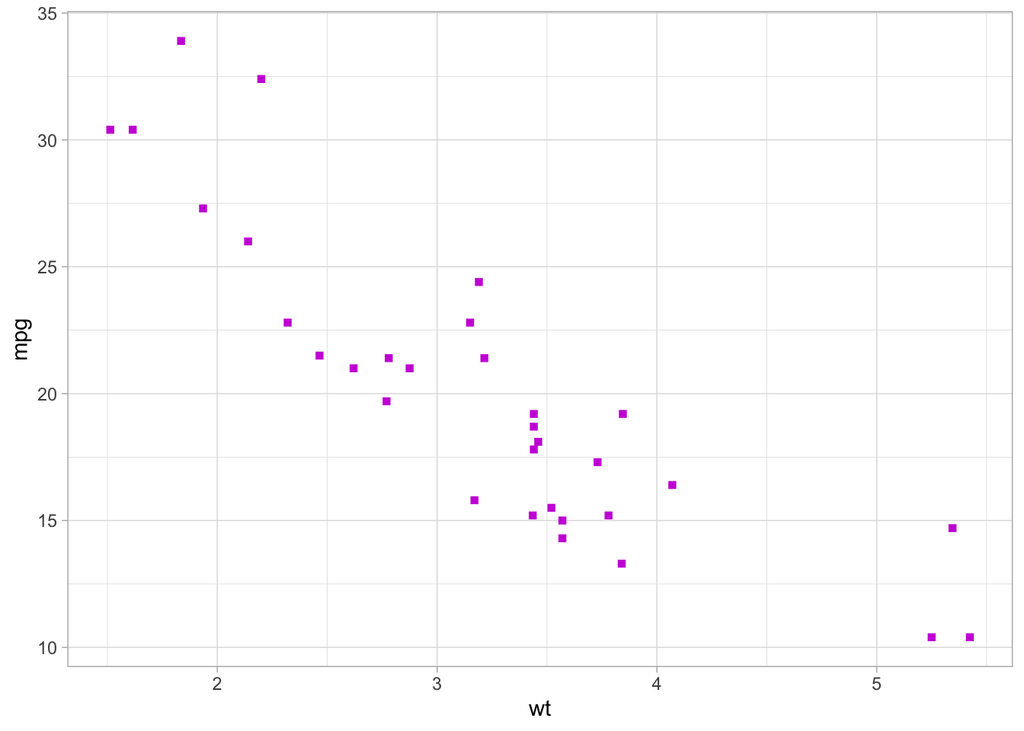

```r
# change color outside of aes()

mtcars |>
ggplot() +
  geom_point(aes(x=wt, y=mpg),
             shape=15,
             color="#cb18db") +
  theme_light()
```